# What Is Representation Learning?

Introductory lecture · Geometry of Embeddings

Built on Chapters 1–2 of Buchanan et al. (2025); figures are taken from there.

## Today

1. **What is a representation?** An encoder that maps data to features
2. **Why can we learn one?** Real data have **low-dimensional structure**
3. **Classical models:** PCA → ICA → sparse coding
4. **Deep models:** sparse autoencoders, denoising and diffusion
5. **What makes a representation good?**

# What is a representation?

## Encoders, decoders, features

$$\mathbf x \in \mathbb R^D \;\xrightarrow{\;f\;}\; \mathbf z \in \mathbb R^d \;\xrightarrow{\;g\;}\; \hat{\mathbf x}$$

- $f$ is the **encoder**, $\mathbf z$ the **representation** (embedding, features, code), $g$ an optional **decoder**
- Examples: word embeddings, image features of a vision model, hidden states of a language model
- A representation is useful if it makes later tasks easy: classification, retrieval, generation, prediction (Bengio, Courville, and Vincent 2013, Meeting 2)

**This seminar** asks what the **geometry** of $\mathbf z$ tells us: which directions, distances and clusters carry meaning, and whether different models arrive at the same geometry.

# Why can we learn one?

## Predictability means low dimensionality

Take a sequence where each value depends on the previous $d$ values, e.g. $x_{n+2} = a x_{n+1} + b x_n$. Cut it into windows of length $D \gg d$: each window is fixed by its first $d$ entries, so all windows lie on a **$d$-dimensional** set in $\mathbb R^D$.

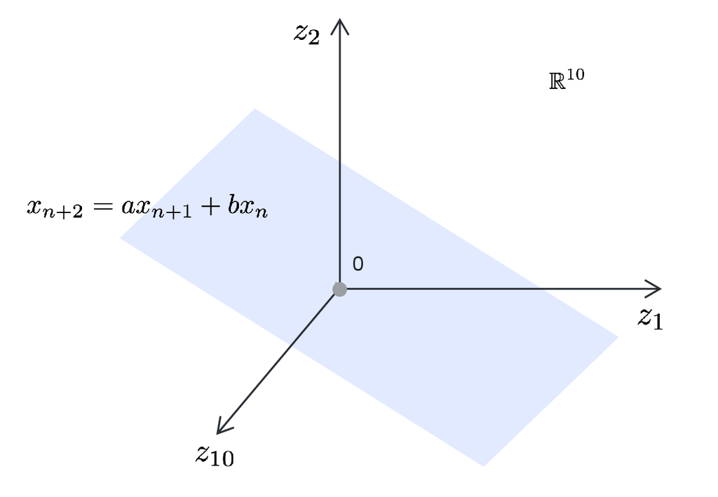

Windows in $\mathbb R^{10}$ lie on a 2-D plane. Finding the plane recovers $a$ and $b$.

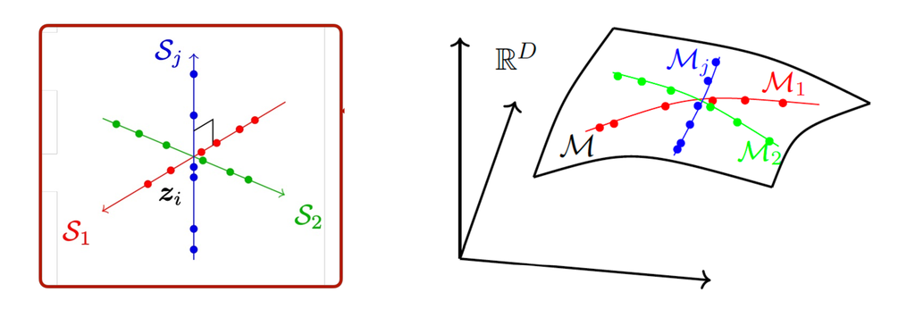

Real data mix several structures: unions of subspaces (left) or of manifolds (right).

## Predictability means low dimensionality

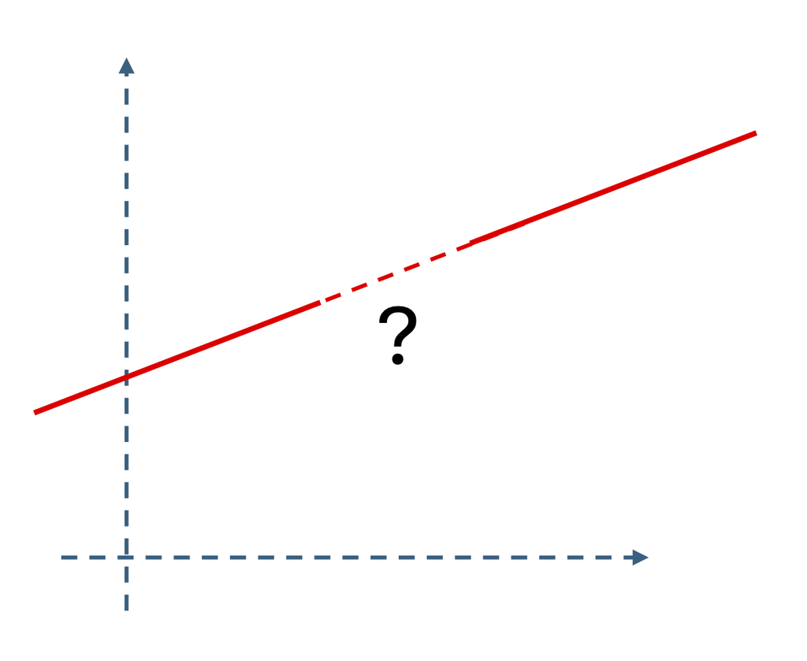

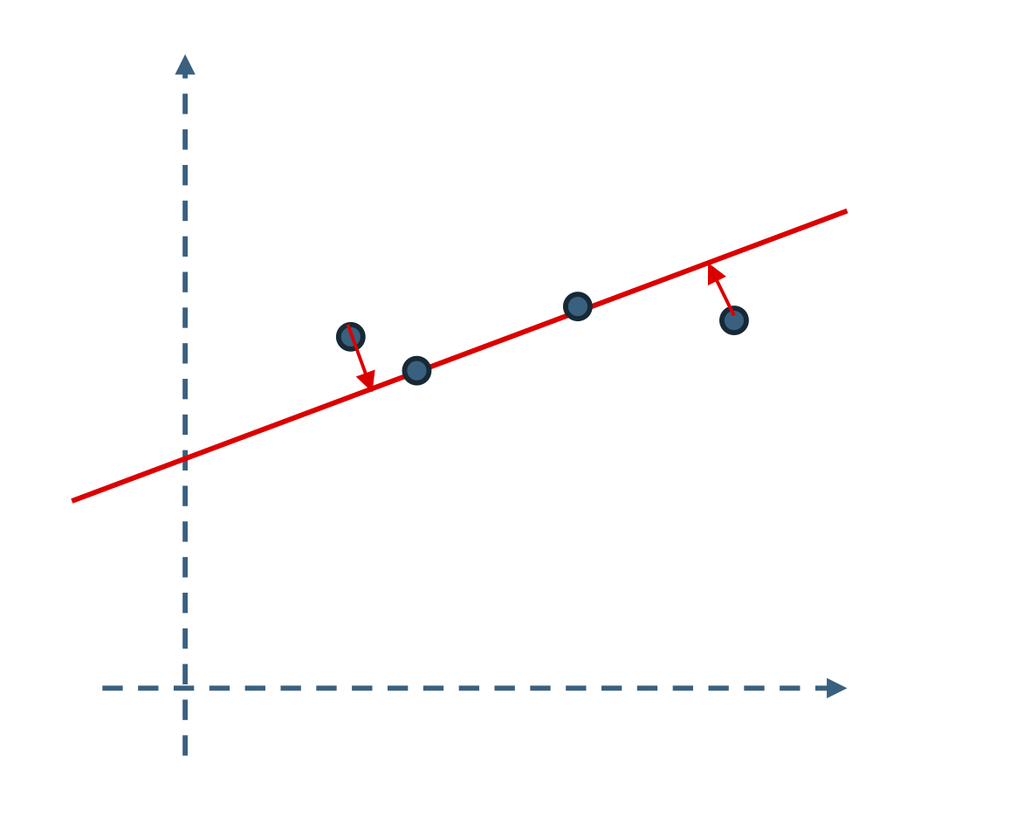

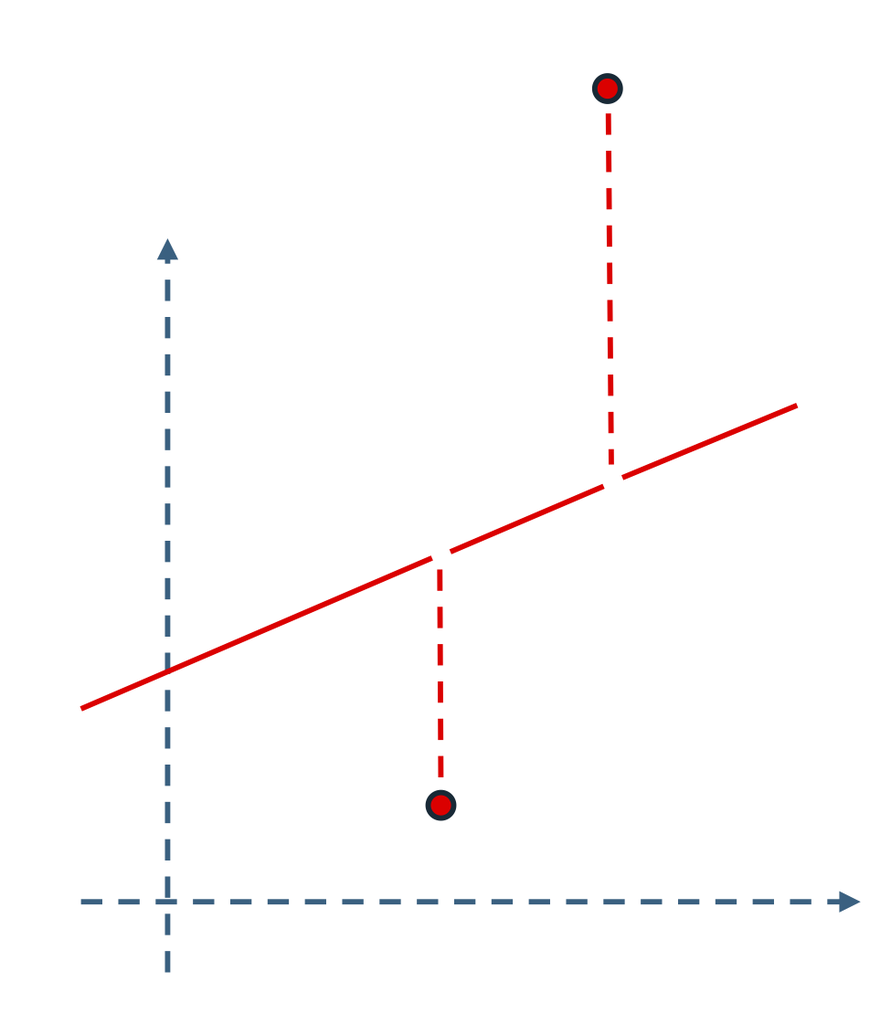

Completion · denoising · error correction, when data lie on a line in the plane

If we know the structure, we can fill in missing entries, remove noise and correct errors. With noise, data are “low-dimensional” when their density **concentrates near** such a set.

**Working assumption (manifold hypothesis):** high-dimensional data have **low-dimensional support**. Representation learning means finding it.

# Classical models

## PCA: one subspace

Model: $\mathbf x = \mathbf U \mathbf z + \boldsymbol\varepsilon$, with $\mathbf U \in \mathbb R^{D \times d}$ orthonormal and $d \ll D$.

$$\min_{\mathbf U} \; \frac1N \sum_{i=1}^N \big\lVert \mathbf x_i - \mathbf U \mathbf U^\top \mathbf x_i \big\rVert_2^2
\quad\Rightarrow\quad \mathbf U = \text{top-}d \text{ eigenvectors of } \tfrac1N \mathbf X \mathbf X^\top$$

- An **autoencoder** with encoder $f = \mathbf U^\top$ and decoder $g = \mathbf U$: a two-layer linear network with tied weights
- $\mathbf U \mathbf U^\top$ is the best **linear denoiser**: it projects noisy points back onto the subspace
- **Limitation:** the loss does not change if we rotate $\mathbf U$. PCA finds the subspace, but **not a meaningful basis** inside it.

## ICA: choosing the right basis

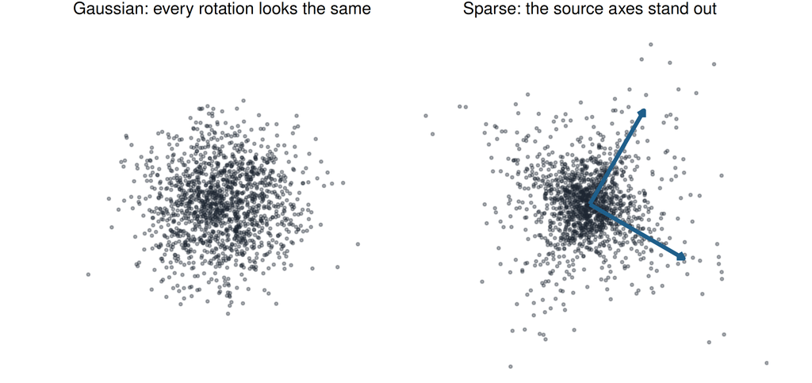

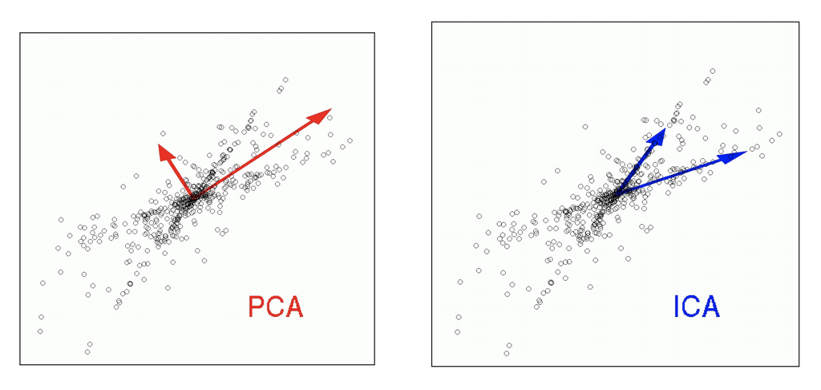

- Assume the coordinates $z_i$ are **independent** and **non-Gaussian**
- Gaussians look the same in every rotation, so PCA cannot pick a basis. Non-Gaussian data break this symmetry.
- **Kurtosis** $\mathbb E[z^4] - 3(\mathbb E[z^2])^2$ is zero for Gaussians and large for heavy-tailed, sparse signals. Maximising it recovers the independent directions.

## Sparse coding: many subspaces

Each data point uses only a few **atoms** (columns) of a dictionary $\mathbf A$. Example with 4 atoms, 2 of them active:

$$\underbrace{\begin{pmatrix} x_1 \\ x_2 \\ x_3 \end{pmatrix}}_{\mathbf x} =
\underbrace{\begin{pmatrix}
{a_{11}} & {a_{12}} & {a_{13}} & {a_{14}} \\
{a_{21}} & {a_{22}} & {a_{23}} & {a_{24}} \\
{a_{31}} & {a_{32}} & {a_{33}} & {a_{34}} \\
\end{pmatrix}}_{\mathbf A}
\underbrace{\begin{pmatrix} {z_1} \\ {0} \\ {z_3} \\ 0 \end{pmatrix}}_{\mathbf z} =
z_1 {\mathbf a_1} + z_3 {\mathbf a_3}$$

- $\mathbf x$ lies in the plane spanned by $\mathbf a_1, \mathbf a_3$. In general $\mathbf x = \mathbf A \mathbf z + \boldsymbol\varepsilon$ with $\lVert \mathbf z \rVert_0 \ll D$: each choice of active atoms is a subspace, so the data lie on a **union of subspaces**
- **Overcomplete** dictionaries (more atoms than dimensions) are more expressive. Trained on image patches, their atoms become **oriented edges**, much like receptive fields in early visual cortex (Olshausen and Field 1996).
- Finding $\mathbf z$ is a convex problem (LASSO): $\;\min_{\mathbf z} \lVert \mathbf x - \mathbf A \mathbf z \rVert_2^2 + \lambda \lVert \mathbf z \rVert_1$

## Sparse autoencoders: reading deep representations

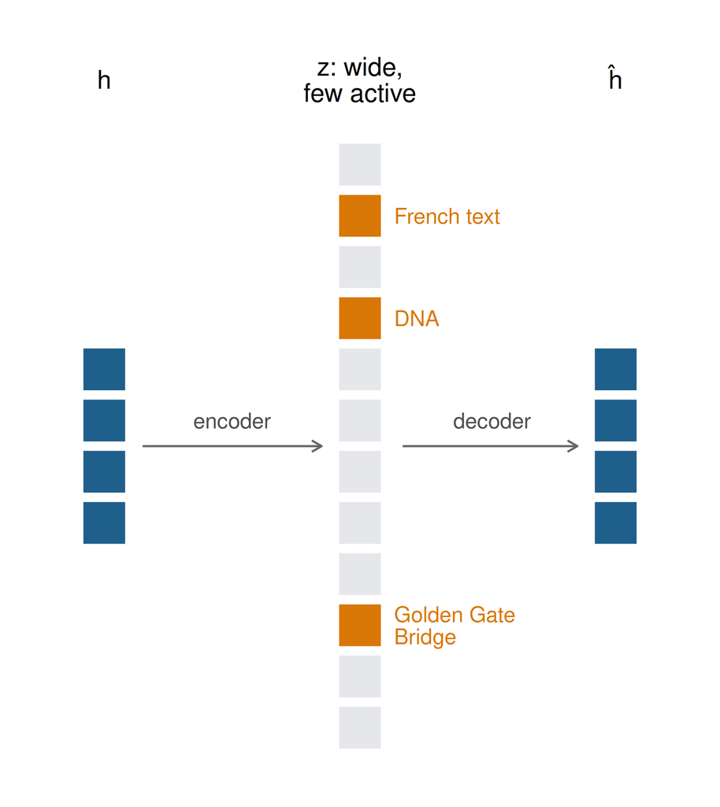

Apply sparse coding to the **hidden states** $\mathbf h$ of a trained network:

$$\begin{aligned}
\mathbf z &= \operatorname{ReLU}(\mathbf W \mathbf h + \mathbf b) \\
\hat{\mathbf h} &= \mathbf A \mathbf z \\
\min \;& \lVert \mathbf h - \hat{\mathbf h} \rVert_2^2 + \lambda \lVert \mathbf z \rVert_1
\end{aligned}$$

- **Superposition hypothesis:** a network stores more features than it has dimensions, as sparse combinations of directions (Elhage et al. 2022)
- If this holds, an overcomplete SAE dictionary recovers **interpretable features** of language models (Huben et al. 2024)

# Deep models

## Denoising as learning a distribution

For a noisy point $\mathbf x = \mathbf x_o + \sigma \mathbf g$, the best denoiser is given by **Tweedie’s formula**:

$$\mathbb E[\mathbf x_o \mid \mathbf x] = \mathbf x + \sigma^2 \nabla \log p(\mathbf x)$$

- The **score** $\nabla \log p$ points toward regions of high density. PCA’s projection is the special case of a single subspace.
- Repeated denoising concentrates probability mass on low-dimensional structure.

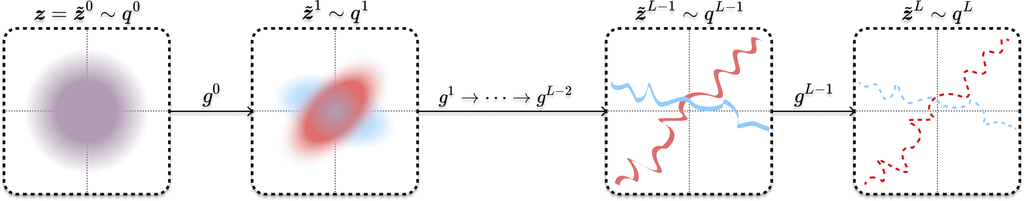

A sequence of maps turns a Gaussian into a distribution on a union of low-dimensional sets.

## Deep networks: same goal, fewer guarantees

- Classical models assume (piecewise) **linear** structure and come with **guarantees**
- Deep networks (CNNs, ResNets, Transformers) handle **nonlinear** structure and work very well, but the evidence is mostly empirical

**This seminar:** we can train representations that work, but we only partly understand *what* they represent and *why* these architectures find it. That gap is what this seminar is about.

# What makes a representation good?

## Four criteria

1. **Compressed:** few bits per data point. Measured by the **coding rate**, a computable stand-in for Kolmogorov complexity.
2. **Structured:** compression alone is not enough, since optimal codes look random. Different parts of the data should map to clearly separated, near-orthogonal subspaces.
3. **Consistent:** we can decode $\mathbf z$ back to $\mathbf x$ (autoencoding).
4. **Self-consistent:** re-encoding the decoded $\hat{\mathbf x}$ gives back $\mathbf z$. The check happens in feature space, not data space.

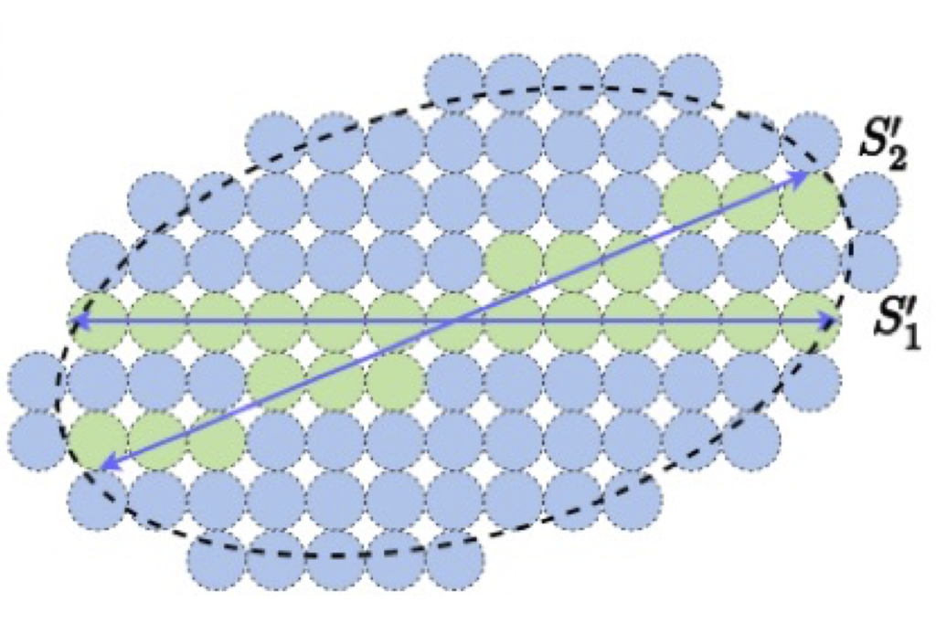

Knowing the structure lets us cover the data with far fewer $\epsilon$-balls (green vs. blue).

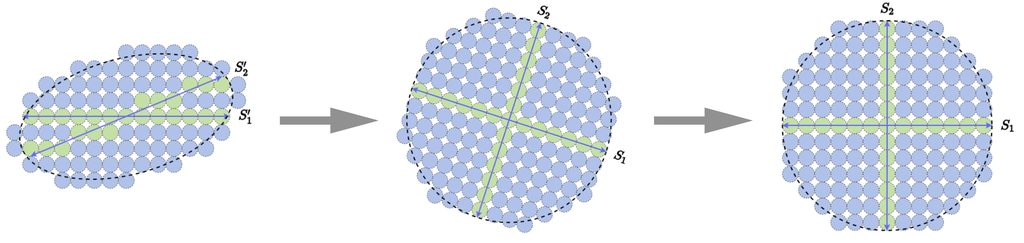

## For discussion

1. **The working assumption.** Is “low-dimensional support” an empirical finding, a modelling choice, or a definition of what is learnable? (manifold hypothesis, Bengio, Courville, and Vincent 2013, Meeting 2)
2. **Identifiability.** PCA cannot choose a basis; ICA needs independence. Locatello et al. (2019) show that data alone do not identify the factors. What extra assumptions do deep models make?
3. **Directions as meaning.** Sparse autoencoders assume features are directions. When is that plausible, and when do features curve or split?
4. **Convergence.** If every good learner compresses the same low-dimensional world, should representations converge? (Platonic Representation Hypothesis, Huh et al. 2024, Meeting 3)

## References

Bengio, Yoshua, Aaron C. Courville, and Pascal Vincent. 2013. “Representation Learning: A Review and New Perspectives.” *IEEE Trans. Pattern Anal. Mach. Intell.* 35 (8): 1798–828. https://doi.org/10.1109/TPAMI.2013.50.

Buchanan, Sam, Druv Pai, Peng Wang, and Yi Ma. 2025. *Principles and Practice of Deep Representation Learning*. Online.

Elhage, Nelson, Tristan Hume, Catherine Olsson, Nicholas Schiefer, Tom Henighan, Shauna Kravec, Zac Hatfield-Dodds, et al. 2022. “Toy Models of Superposition.” *CoRR* abs/2209.10652. https://doi.org/10.48550/ARXIV.2209.10652.

Huben, Robert, Hoagy Cunningham, Logan Riggs Smith, Aidan Ewart, and Lee Sharkey. 2024. “Sparse Autoencoders Find Highly Interpretable Features in Language Models.” In *The Twelfth International Conference on Learning Representations, ICLR 2024, Vienna, Austria, May 7-11, 2024*. OpenReview.net. https://openreview.net/forum?id=F76bwRSLeK.

Huh, Minyoung, Brian Cheung, Tongzhou Wang, and Phillip Isola. 2024. “Position: The Platonic Representation Hypothesis.” In *Forty-First International Conference on Machine Learning, ICML 2024, Vienna, Austria, July 21-27, 2024*, edited by Ruslan Salakhutdinov, Zico Kolter, Katherine A. Heller, Adrian Weller, Nuria Oliver, Jonathan Scarlett, and Felix Berkenkamp, 235:20617–42. Proceedings of Machine Learning Research. PMLR / OpenReview.net. https://proceedings.mlr.press/v235/huh24a.html.

Locatello, Francesco, Stefan Bauer, Mario Lucic, Gunnar Rätsch, Sylvain Gelly, Bernhard Schölkopf, and Olivier Bachem. 2019. “Challenging Common Assumptions in the Unsupervised Learning of Disentangled Representations.” In *Proceedings of the 36th International Conference on Machine Learning, ICML 2019, 9-15 June 2019, Long Beach, California, USA*, edited by Kamalika Chaudhuri and Ruslan Salakhutdinov, 97:4114–24. Proceedings of Machine Learning Research. PMLR. http://proceedings.mlr.press/v97/locatello19a.html.

Olshausen, Bruno A, and David J Field. 1996. “Emergence of Simple-Cell Receptive Field Properties by Learning a Sparse Code for Natural Images.” *Nature* 381 (6583): 607–9.